# OOPS

- Scope Resolution Operator

## Scope Resolution Operator

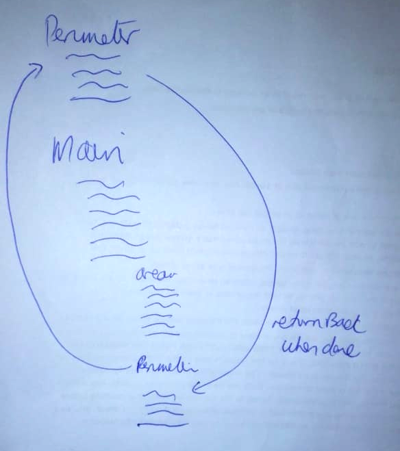

As seen we can only write the prototype or "skeleton" of the function:

```
class Rectangle{
private:
...
public:
   ...
   int perimeter();
   ...
}
```

Where do we write the actual function. We write it outside the class, using **class name** and **scope resolution**

```
int Rectangle::perimeter(){
        return 2 *( length + breadth);
}
```

But what is the difference between area function where it has its actual body in clase, and perimeter function, which only has the prototype in class, but body outside the class?

When the program is complied it is converted into machine code. How does the machine code look like. Lets explore...

Inside Main code, **area** function (body) will be written. This is called **INLINE Function**, and we should put **simple**, not complex (*loops or nested loops, etc) code, in here.Its not seperate code, its part of main.

Whereas **perimeter** function (body) will be written outside main, and will when it is needed will be referenced, and then execution will return when its done, back to main. This is the **preferred way** of how things should be defined.

So if function is inside a class with its body, it is autotically INLINE, and if function body is outside a class it is automatically a separate class (when object or machine code is generated).

But we can make it inline, by adding inline keyword infront:

```
inline int perimeter();
```

Now, the body may be outside, but when the machine code is generated, it will not be a separate function.

### this pointer

```
private:
    int length;
    int breadth;
public:

    Rectangle(int length, int breadth){
        length = length;
        breadth = breadth
    }
```

Which lenth gets set?? to avoid the above ambiguity, we use the this-> pointer

```
Rectangle(int length, int breadth){
    this->length = length;
    this->breadth = breadth
}
```

this-> is used to refer to members of current function

```python
#include <iostream>
#include <climits>
#include <math.h>
using namespace std;
```

```python
class Rectangle{
private:
    int length;
    int breadth;
public:

    Rectangle(int l, int b ){
        setlength (l);
        setbreadth(b);
    }

    void setlength(int l){
        if (l <0){
          length = 1;
        }
        else
        {
          length = l;
        }

    }

    void setbreadth(int b){
        if (b <0){
          breadth = 1;
        }
        else
        {
          breadth = b;
        }

    }

    int area(){
        return length * breadth;
    }

    int perimeter();

}
```

```python
int Rectangle::perimeter(){
        return 2 *( length + breadth);
}
```

```python
Rectangle r(10,5);
```

```python
cout<<r.area()<<endl;
cout<<r.perimeter()<<endl;
```

```
50
30
```